# POLS 2072Q

Lecture 14 | Exploring Two Variables at at Time

## Today’s Question

Looking at the scatter plot of two variables, we can get a sense of:

1. the sign of the correlation between the two variables
2. the sign of the slope of the line of best fit
3. both (A) and (B); they are the same
4. none of the above

## Plan for Today

- Exploring the Relationship Between Two Variables
  - Scatter plots
  - Correlations

## Review

- Last class, we saw how to explore **one variable** at a time
  - Creating table of frequencies and/or proportions
  - Creating histograms
  - Computing descriptive statistics: mean, median, standard deviation, and variance
- Most data analyses are about understanding the relationship between two variables
- To explore the **relationship between two variables** we
  - Create scatter plots
  - Compute correlation coefficient

## Scatter Plot

- A **scatter plot** enables us to visualize the relationship between two variables by plotting one variable against the other in the two-dimensional space

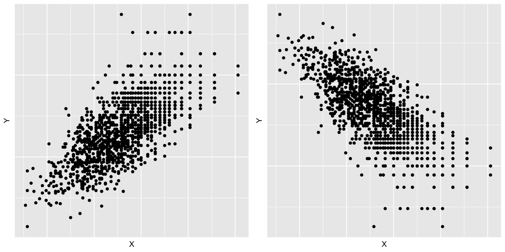

- R function:
  - Tidyverse: `geom_point()`
  - Base R: `plot()`
- How many arguments are required?
  - two (x and y)
- Enter arguments in the expected order: first X, second Y
- Let’s use the data from Project STAR

```r
#read in the data
star <- read.csv("STAR.csv")


#examine the data
head(star)
```

```
##   classtype reading math graduated
## 1     small     578  610         1
## 2   regular     612  612         1
## 3   regular     583  606         1
## 4     small     661  648         1
## 5     small     614  636         1
## 6   regular     610  603         0
```

- Unit of observation?
  - Students
- Unit of measurement of *reading* and *math*?
  - Points
- Let’s create a scatter plot between reading and math, where reading is on the x-axis and math is on the y-axis?

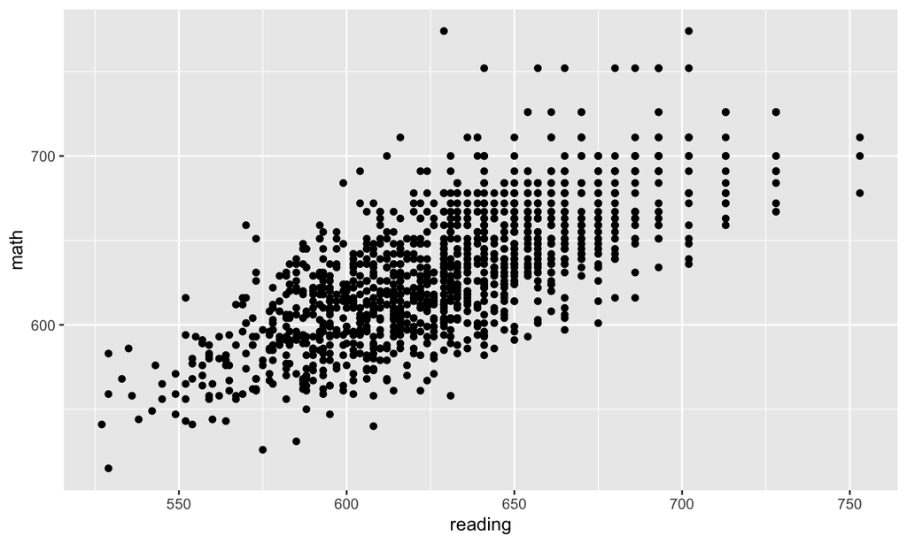

```r
#tidyverse
ggplot(data = star) +
  geom_point(mapping = aes(x = reading, y = math))
```

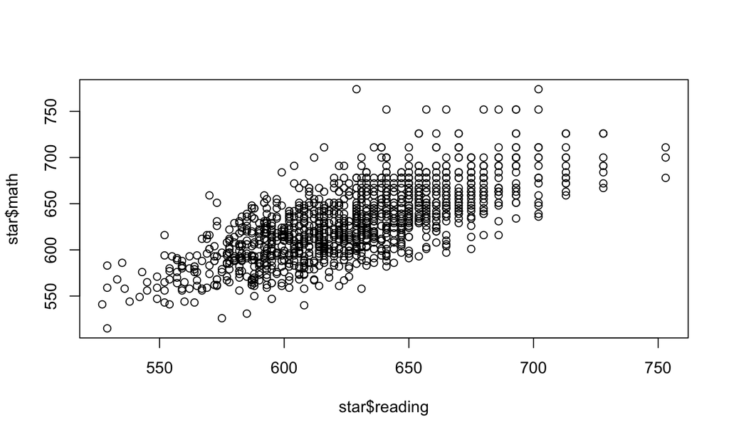

```r
#base R
plot(star$reading, star$math)
```

- What can we learn from this scatter plot about the relationship between these two variables?
  - Do students who tend to do well in one exam also tend to do well in the other?

## Correlation Coefficient

- The **correlation coefficient** or **correlation** is a statistic that summarizes the relationship between two variables with a number
  - Denoted as `cor(x,y)`
- `cor(X,Y)` summarizes the **direction** and the **strength** of the **linear association** between the two variables, X and Y
- Correlations range from -1 to 1
- The sign reflects the **direction** of the linear association:
  - cor(X,Y) > 0 if the slope of the line of best fit is positive
  - cor(X,Y) < 0 if the slope of the line of best fit is negative
- The absolute value reflects the **strength** of the linear association:
  - |cor(X,Y)| = 0 if there is no linear association
  - |cor(X,Y)| = 1 if there is a perfect linear association
  - |cor(X,Y)| increases as the observations move closer to the line of best fit and the linear association becomes stronger
- Example of change in **direction** of the linear association between two variables:

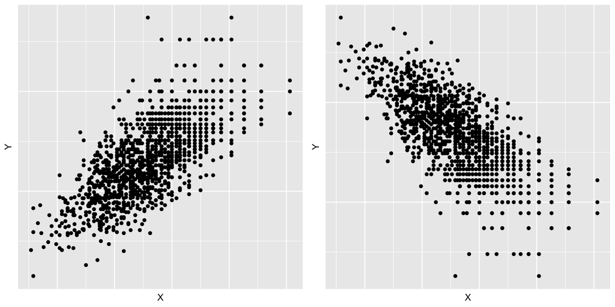

Positive linear association vs. negative linear association

positive correlation vs. negative correlation

- Example of change in **strength** of the linear association between two variables:

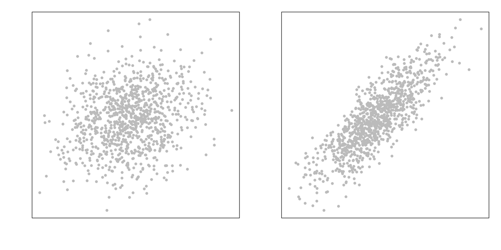

weak linear association vs. strong linear association

absolute value close to 0 vs. absolute value close to 1

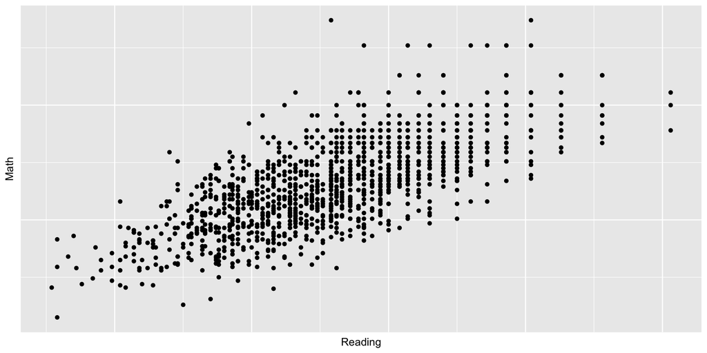

- Is the slope of the line of best fit positive or negative?
- Do you expect the correlation between reading and math to be positive or negative?

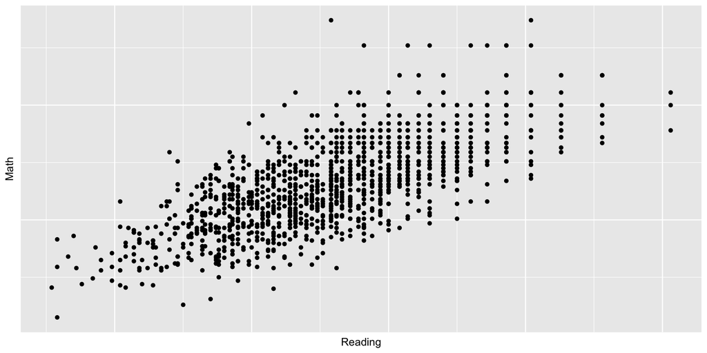

- Does the association look strongly linear?
- Do you expect the absolute value of the correlation between reading and math to be closer to 1 or to 0?
- R function: `cor()`
- How many required arguments?
  - two (x,y)
- Does the order of the arguments matter?
  - not really; cor(x,y) = cor(y,x)
- Example

```r
cor(star$reading, star$math)
```

```
## [1] 0.7161218
```

```r
#or

cor(star$math, star$reading)
```

```
## [1] 0.7161218
```

- Is the correlation what we expected?

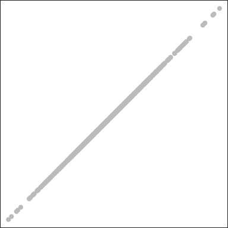

Sign and slope of best line? ____

Strong linear associate? ____

cor(x,y) = ____

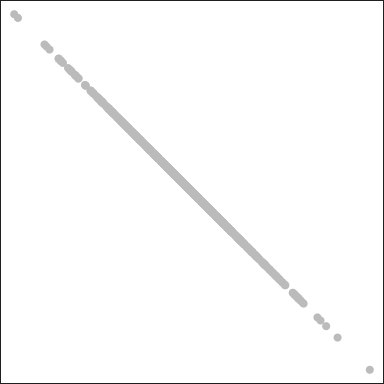

Sign and slope of best line? ____

Strong linear associate? ____

cor(x,y) = ____

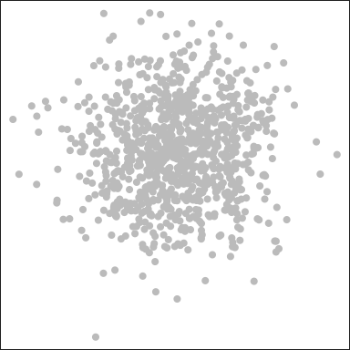

Sign and slope of best line? ____

Strong linear associate? ____

cor(x,y) = ____

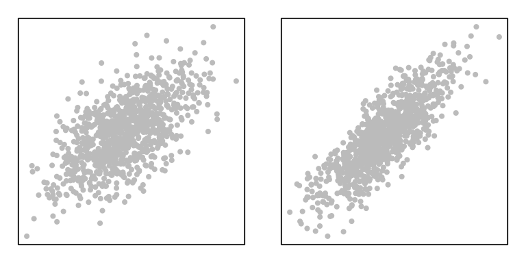

The correlation in the second scatter plot is ____ (higher/lower) than the correlation in the first scatter plot?

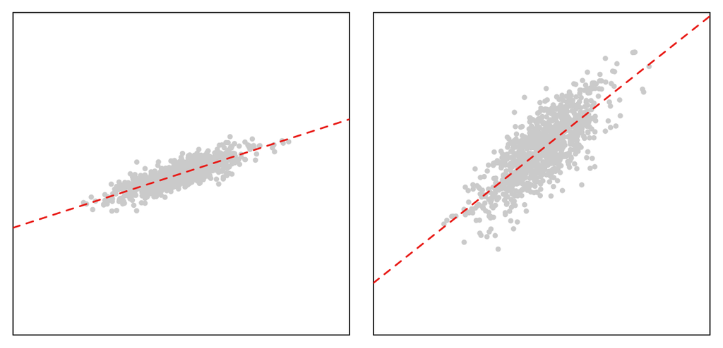

Line of best fit is steeper in ____ (first/second) scatter plot?

Correlation is higher in ____ (first/second) scatter plot?

- A steeper line of best fit does not necessarily mean a higher correlation in absolute terms, or vice versa

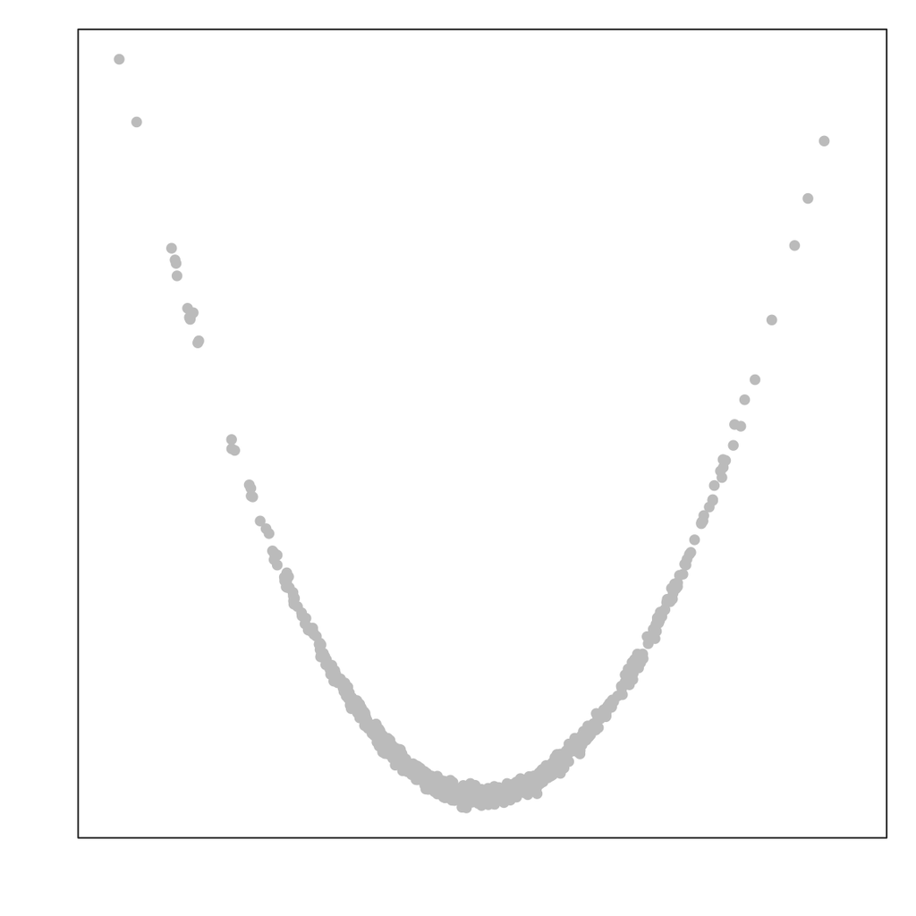

- cor(x,y) \(\approx\) 0
- Does this mean that there is no relationship between the two variables? No, it just means that there is no linear relationship between the two variables
- If two variables have a correlation of zero, it does not necessarily mean that there is no relationship between them

## Correlation Does not Imply Causation

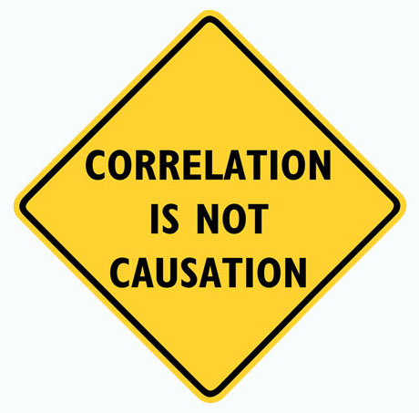

- Correlation does not necessarily imply causation
- Just because two variables have a strong linear association does not mean that changes in one variable cause changes in the other
- Example: Ice cream sales and murder rates are highly correlated with each other…
- More on this later in the semester!

## For Next Class

- Review what you learned today
- Lab
- Exam 1